# BIO 381: Computational Biology

Ethan Thibault

1/17/2018

## Introduction

This webpage is a compilation of a semester’s worth of work in BIO 381 (Computational Biology). As you move through, you will encounter sequentially, my assignments and anything fun I learn how to do.

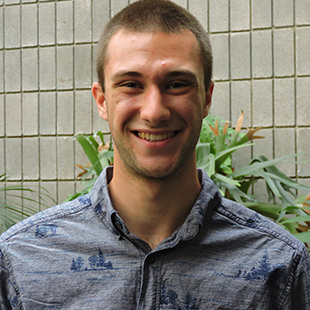

#### Ethan Thibault

**Office:** Jeffords Hall 324  
**Email:** eathibau@uvm.edu

## Helpful Links

- [Course Webpage](https://gotellilab.github.io/Bio381/)
- [RMarkdown Cheatsheet](https://www.rstudio.com/wp-content/uploads/2015/02/rmarkdown-cheatsheet.pdf)
- [Github website templates](https://github.com/jekyll/jekyll/wiki/Themes)
- [R help](http://stackoverflow.com/questions/tagged/r)

## Homework Solutions and Notes

### Week 1: Setting up a webpage

[Assignment Page](https://gotellilab.github.io/Bio381/Homeworks/Homework01.html)

Due:  
1. A fun fact about yourself  
2. Your github homepage  
3. Your BIO 381 webpage

No solution

### Week 2: Creating Flowcharts

Due:  
1. Create two diagrams in Typora  
2. Create a link from webpage to my diagrams  
3. Commit and publish to GitHub webpage

Typora Diagrams

### Week 3: Creating a Beamer Presentation

Due: A beamer presentation with:  
1. sequential bullet points 2. simultaneous bullet points 3. colored text 4. images 5. images with captions 6. images with a caption overlaid (you may need to change the text color for better contrast)

Beamer Presentation

### Week 4: Regular Expressions

Due: Problem Set

### Week 5: Regular Expressions

Due: Problem Set

### Week 6: Probability and Distributions 2

Due: Problem Set

### Week 7: Creating Fake Data Sets To Explore Hypotheses

Here I am making functions that will model my data.

This is a combination of two weeks of work

Due: Hypotheses Exploration

### Week 8: Homework 10: Batch processing (continued)

Link to Homework 10

### Week 9: Homework 11

Here is the link to homework 11.

### Week 10: Homework 12: ggplot

Here is a link to my homework 12

### Week 11: Student Presentation

Here is the link to the page I will be working off of for my presentation on igraph!